# Project 2: Data Mining, Classification, Prediction

### Non-Parametric Classifier

```r
library(caret)
fit <- knn3(Window ~ RI + Na + Mg + Al + Si + K + Ca + Ba + Fe,
    data = glass)
probs <- predict(fit, newdata = glass)[, 2]
class_diag(probs, truth = glass$Window, positive = 1)
```

```
##            acc   sens   spec    ppv     f1     ba    auc
## Metrics 0.9579 0.9886 0.8158 0.9613 0.9748 0.9022 0.9936
```

```r
table(truth = glass$Window, predictions = probs > 0.5)
```

```
##      predictions
## truth FALSE TRUE
##     0    31    7
##     1     2  174
```

```r
# data.frame(probs, glass$Window)
```

```r
set.seed(1234)
k = 10

data <- sample_frac(glass)
folds <- cut(1:nrow(glass), breaks = k, labels = F)

diags <- NULL


for (i in 1:k) {
    train <- data[folds != i, ]
    test <- data[folds == i, ]
    truth <- test$Window
    fit <- knn3(Window ~ RI + Na + Mg + Al + Si + K + Ca + Ba +
        Fe, data = train)
    prob <- predict(fit, newdata = test)[, 2]
    diags <- rbind(diags, class_diag(prob, truth, positive = 1))
}
summarize_all(diags, mean)
```

```
##      acc    sens    spec     ppv      f1      ba     auc
## 1 0.9435 0.98199 0.74571 0.94989 0.96534 0.86386 0.96317
```

Since there is not a huge drop in the AUC from the single case to the cross validated case, there was likely some over-fitting but not a terrible amount. The AUC for the whole dataset was 0.9936 compared to 0.96 for the cross validated data. Either model is likely good but the cross validated model is more likely to continue to predict new data with this accuracy as it comes in. In both cases, specificity seems a bit low (especially compared to the other data) this is likely due, in part to an imbalance in the data set. Here true negatives are low.

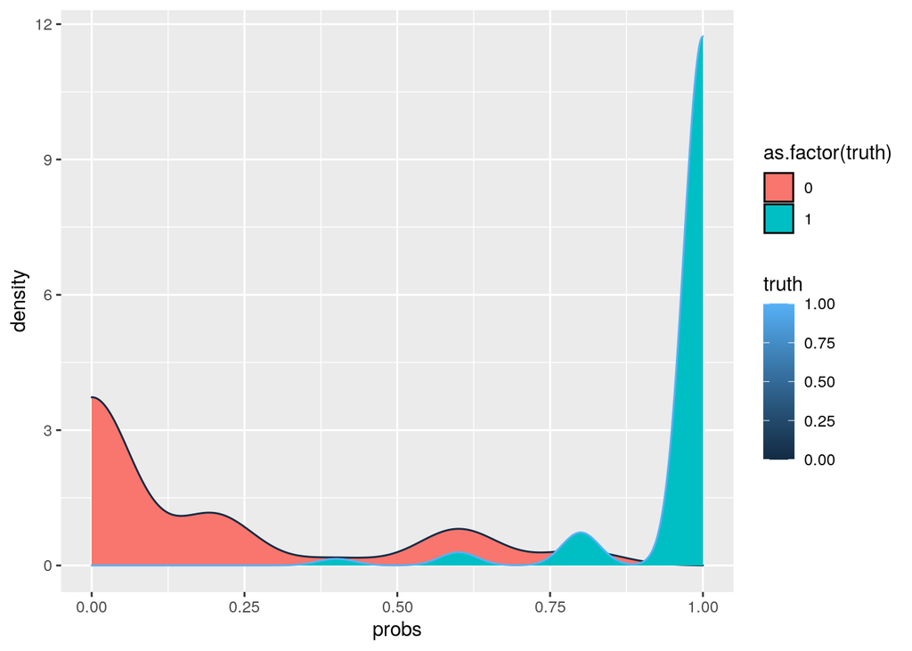

```r
data.frame(probs, truth = glass$Window) %>% ggplot(aes(probs,
    color = truth)) + geom_density(aes(fill = as.factor(truth)))
```